# Effects of Major Storm Events on U.S. Population Health and Economy

Ashly Yashchin

6/6/2017

## Synopsis

Our analysis on the NOAA storm database begins with a quick cleanup of the data, which contained more than 900 different classifiers for storm event types, when there should only be 48. From there, we broke the data into two sets for analysis on health and economic impact respectively. We found that hurricanes are mutually threatening, having a high impact on human health and economic outcomes per event occurence. Other events differed (i.e. heat has a large human health impact but little economic impact and floods have a significantly higher economic impact than human health). The purpose of this analysis was to provide tables and figures that would allow officials to make decisions on extreme weather event preparations.

## Loading and Processing the Raw Data

This data has been provided by the U.S. National Oceanic and Atmospheric Administration’s (NOAA) storm database. It can be found [here](https://d396qusza40orc.cloudfront.net/repdata%2Fdata%2FStormData.csv.bz2). The supporting data documentation can be found in National Weather Service Instruction document located [here](https://d396qusza40orc.cloudfront.net/repdata%2Fpeer2_doc%2Fpd01016005curr.pdf).

### Reading in the Data

```r
dataUrl <- "https://d396qusza40orc.cloudfront.net/repdata%2Fdata%2FStormData.csv.bz2"

if(!file.exists("./data")){dir.create("./data")}
if(!file.exists("./data/NOAA_storm_data.zip")){
  download.file(dataUrl,destfile="./data/NOAA_storm_data.zip")}
if(!exists("NOAAdata")){
                NOAAdata <- read.csv("./data/NOAA_storm_data.zip",header=TRUE,sep=",")}
dim(NOAAdata)
```

```
## [1] 902297     37
```

```r
head(NOAAdata)
```

```
##   STATE__           BGN_DATE BGN_TIME TIME_ZONE COUNTY COUNTYNAME STATE
## 1       1  4/18/1950 0:00:00     0130       CST     97     MOBILE    AL
## 2       1  4/18/1950 0:00:00     0145       CST      3    BALDWIN    AL
## 3       1  2/20/1951 0:00:00     1600       CST     57    FAYETTE    AL
## 4       1   6/8/1951 0:00:00     0900       CST     89    MADISON    AL
## 5       1 11/15/1951 0:00:00     1500       CST     43    CULLMAN    AL
## 6       1 11/15/1951 0:00:00     2000       CST     77 LAUDERDALE    AL
##    EVTYPE BGN_RANGE BGN_AZI BGN_LOCATI END_DATE END_TIME COUNTY_END
## 1 TORNADO         0                                               0
## 2 TORNADO         0                                               0
## 3 TORNADO         0                                               0
## 4 TORNADO         0                                               0
## 5 TORNADO         0                                               0
## 6 TORNADO         0                                               0
##   COUNTYENDN END_RANGE END_AZI END_LOCATI LENGTH WIDTH F MAG FATALITIES
```

[output cut: 20 more lines]

### Processing the Raw Data

First, let’s clean up the data. There are 48 valid Storm Data Event listed in the [NWSI supporting documentation](https://d396qusza40orc.cloudfront.net/repdata%2Fpeer2_doc%2Fpd01016005curr.pdf) on page 6 in table 2.1.1.

```r
str(NOAAdata)
```

```
## 'data.frame':    902297 obs. of  37 variables:
##  $ STATE__   : num  1 1 1 1 1 1 1 1 1 1 ...
##  $ BGN_DATE  : Factor w/ 16335 levels "1/1/1966 0:00:00",..: 6523 6523 4242 11116 2224 2224 2260 383 3980 3980 ...
##  $ BGN_TIME  : Factor w/ 3608 levels "00:00:00 AM",..: 272 287 2705 1683 2584 3186 242 1683 3186 3186 ...
##  $ TIME_ZONE : Factor w/ 22 levels "ADT","AKS","AST",..: 7 7 7 7 7 7 7 7 7 7 ...
##  $ COUNTY    : num  97 3 57 89 43 77 9 123 125 57 ...
##  $ COUNTYNAME: Factor w/ 29601 levels "","5NM E OF MACKINAC BRIDGE TO PRESQUE ISLE LT MI",..: 13513 1873 4598 10592 4372 10094 1973 23873 24418 4598 ...
##  $ STATE     : Factor w/ 72 levels "AK","AL","AM",..: 2 2 2 2 2 2 2 2 2 2 ...
##  $ EVTYPE    : Factor w/ 985 levels "   HIGH SURF ADVISORY",..: 834 834 834 834 834 834 834 834 834 834 ...
##  $ BGN_RANGE : num  0 0 0 0 0 0 0 0 0 0 ...
##  $ BGN_AZI   : Factor w/ 35 levels "","  N"," NW",..: 1 1 1 1 1 1 1 1 1 1 ...
##  $ BGN_LOCATI: Factor w/ 54429 levels ""," Christiansburg",..: 1 1 1 1 1 1 1 1 1 1 ...
##  $ END_DATE  : Factor w/ 6663 levels "","1/1/1993 0:00:00",..: 1 1 1 1 1 1 1 1 1 1 ...
##  $ END_TIME  : Factor w/ 3647 levels ""," 0900CST",..: 1 1 1 1 1 1 1 1 1 1 ...
##  $ COUNTY_END: num  0 0 0 0 0 0 0 0 0 0 ...
```

[output cut: 23 more lines]

When we run the str function on EVTYPE we can see that there are 985 different classifiers actually being used in the observations. Eek. That’s a lot of clean-up. Let’s get started.

Since we’re only concerned with the most influential events, for the purpose of this assignment we will do a quick and “dirty” clean-up with some big generalizations. However, were this for a client, we would have to go through hundreds of questionable events line-by-line and read the notes to determine which of the 48 buckets it most closely falls into instead of making blanket assumptions and leaving some uncategorized. For example, would an event listed as simply “FOG” fall into “DENSE FOG” or “FREEZING FOG”?

```r
library(dplyr)
NOAAdata <- arrange(NOAAdata, EVTYPE)
unique(NOAAdata$EVTYPE)
```

```
##   [1]    HIGH SURF ADVISORY           COASTAL FLOOD
##   [3]  FLASH FLOOD                    LIGHTNING
##   [5]  TSTM WIND                      TSTM WIND (G45)
##   [7]  WATERSPOUT                     WIND
##   [9] ?                              ABNORMAL WARMTH
##  [11] ABNORMALLY DRY                 ABNORMALLY WET
##  [13] ACCUMULATED SNOWFALL           AGRICULTURAL FREEZE
##  [15] APACHE COUNTY                  ASTRONOMICAL HIGH TIDE
##  [17] ASTRONOMICAL LOW TIDE          AVALANCE
##  [19] AVALANCHE                      BEACH EROSIN
##  [21] Beach Erosion                  BEACH EROSION
##  [23] BEACH EROSION/COASTAL FLOOD    BEACH FLOOD
##  [25] BELOW NORMAL PRECIPITATION     BITTER WIND CHILL
##  [27] BITTER WIND CHILL TEMPERATURES Black Ice
##  [29] BLACK ICE                      BLIZZARD
```

[output cut: 479 more lines]

Let’s start by creating a smaller number of event classes in a new column, allowing us to most easily group the data. We will leave the existing EVTYPE column intact to further subset these classes later.

```r
clean_data <- NOAAdata %>% mutate(EVCLASS = EVTYPE) %>% arrange(EVCLASS)
clean_data$EVCLASS <- gsub(".*LOW TIDE.*","ASTRONOMICAL LOW TIDE",clean_data$EVCLASS,ignore.case=TRUE)
clean_data$EVCLASS <- gsub(".*AVALAN.*","AVALANCHE",clean_data$EVCLASS,ignore.case=TRUE)
clean_data$EVCLASS <- gsub(".*WATERSPOUT*","WATERSPOUT",clean_data$EVCLASS,ignore.case=TRUE)
clean_data$EVCLASS <- gsub(".*FUNNEL.*","FUNNEL CLOUD",clean_data$EVCLASS,ignore.case=TRUE)
clean_data$EVCLASS <- gsub(".*TORN.*","TORNADO",clean_data$EVCLASS,ignore.case=TRUE)
clean_data$EVCLASS <- gsub(".*BLIZ.*","BLIZZARD",clean_data$EVCLASS,ignore.case=TRUE)
clean_data$EVCLASS <- gsub(".*FLOO.*","FLOOD",clean_data$EVCLASS,ignore.case=TRUE)
clean_data$EVCLASS <- gsub(".*FREEZ.*","FROST/FREEZE",clean_data$EVCLASS,ignore.case=TRUE)
clean_data$EVCLASS <- gsub(".*COLD.*","COLD/WIND CHILL",clean_data$EVCLASS,ignore.case=TRUE)
clean_data$EVCLASS <- gsub(".*WIND CHILL.*","COLD/WIND CHILL",clean_data$EVCLASS,ignore.case=TRUE)
clean_data$EVCLASS <- gsub(".*DEBRIS.*","DEBRIS FLOW",clean_data$EVCLASS,ignore.case=TRUE)
clean_data$EVCLASS <- gsub(".*FOG.*","FOG",clean_data$EVCLASS,ignore.case=TRUE)
clean_data$EVCLASS <- gsub(".*DROUGHT.*","DROUGHT",clean_data$EVCLASS,ignore.case=TRUE)
clean_data$EVCLASS <- gsub(".*DRY.*","DROUGHT",clean_data$EVCLASS,ignore.case=TRUE)
clean_data$EVCLASS <- gsub(".*DUST.*","DUST",clean_data$EVCLASS,ignore.case=TRUE)
clean_data$EVCLASS <- gsub(".*FROST.*","FROST/FREEZE",clean_data$EVCLASS,ignore.case=TRUE)
clean_data$EVCLASS <- gsub(".*HEAT.*","HEAT/EXCESSIVE HEAT",clean_data$EVCLASS,ignore.case=TRUE)
clean_data$EVCLASS <- gsub(".*RECORD HIGH.*","HEAT/EXCESSIVE HEAT",clean_data$EVCLASS,ignore.case=TRUE)
clean_data$EVCLASS <- gsub(".*RECORD LOW*","COLD/WIND CHILL",clean_data$EVCLASS,ignore.case=TRUE)
clean_data$EVCLASS <- gsub(".*WARM.*","HEAT/EXCESSIVE HEAT",clean_data$EVCLASS,ignore.case=TRUE)
clean_data$EVCLASS <- gsub(".*HOT.*","HEAT/EXCESSIVE HEAT",clean_data$EVCLASS,ignore.case=TRUE)
clean_data$EVCLASS <- gsub(".*HAIL.*","HAIL",clean_data$EVCLASS,ignore.case=TRUE)
clean_data$EVCLASS <- gsub(".*ICE STORM.*","ICE STORM",clean_data$EVCLASS,ignore.case=TRUE)
clean_data$EVCLASS <- gsub(".*ICE.*","FROST/FREEZE",clean_data$EVCLASS,ignore.case=TRUE)
clean_data$EVCLASS <- gsub(".*ICY.*","FROST/FREEZE",clean_data$EVCLASS,ignore.case=TRUE)
clean_data$EVCLASS <- gsub(".*HURRICANE.*","HURRICANE (TYPHOON)",clean_data$EVCLASS,ignore.case=TRUE)
clean_data$EVCLASS <- gsub(".*TYPHOON*","HURRICANE (TYPHOON)",clean_data$EVCLASS,ignore.case=TRUE)
clean_data$EVCLASS <- gsub(".*TROPICAL DEPRESSION.*","TROPICAL DEPRESSION",clean_data$EVCLASS,ignore.case=TRUE)
clean_data$EVCLASS <- gsub(".*TROPICAL.*","TROPICAL STORM",clean_data$EVCLASS,ignore.case=TRUE)
clean_data$EVCLASS <- gsub(".*LIGHTN.*","LIGHTNING",clean_data$EVCLASS,ignore.case=TRUE)
clean_data$EVCLASS <- gsub(".*HAIL.*","HAIL",clean_data$EVCLASS,ignore.case=TRUE)
clean_data$EVCLASS <- gsub(".*CURRENT.*","RIP CURRENT",clean_data$EVCLASS,ignore.case=TRUE)
clean_data$EVCLASS <- gsub(".*SLEET.*","SLEET",clean_data$EVCLASS,ignore.case=TRUE)
clean_data$EVCLASS <- gsub(".*SURGE.*","STORM SURGE/TIDE",clean_data$EVCLASS,ignore.case=TRUE)
clean_data$EVCLASS <- gsub(".*FIRE.*","FIRE",clean_data$EVCLASS,ignore.case=TRUE)
clean_data$EVCLASS <- gsub(".*THUND.*","THUNDERSTORM",clean_data$EVCLASS,ignore.case=TRUE)
clean_data$EVCLASS <- gsub(".*TSTM.*","THUNDERSTORM",clean_data$EVCLASS,ignore.case=TRUE)
clean_data$EVCLASS <- gsub(".*SUMMARY.*","SUMMARIES",clean_data$EVCLASS,ignore.case=TRUE)
clean_data$EVCLASS <- gsub(".*EROSION.*","EROSION",clean_data$EVCLASS,ignore.case=TRUE)
clean_data$EVCLASS <- gsub(".*LANDSLID.*","DEBRIS FLOW",clean_data$EVCLASS,ignore.case=TRUE)
clean_data$EVCLASS <- gsub(".*MUD.*","DEBRIS FLOW",clean_data$EVCLASS,ignore.case=TRUE)
clean_data$EVCLASS <- gsub(".*NORMAL.*","ABNORMAL EVENT",clean_data$EVCLASS,ignore.case=TRUE)
clean_data$EVCLASS <- gsub(".*MICROBURST.*","THUNDERSTORM",clean_data$EVCLASS,ignore.case=TRUE)
clean_data$EVCLASS <- gsub(".*DRY.*","DROUGHT",clean_data$EVCLASS,ignore.case=TRUE)
clean_data$EVCLASS <- gsub(".*VOLCAN.*","VOLCANIC ASH",clean_data$EVCLASS,ignore.case=TRUE)
clean_data$EVCLASS <- gsub(".*GLAZE.*","FROST/FREEZE",clean_data$EVCLASS,ignore.case=TRUE)
clean_data$EVCLASS <- gsub(".*SURF.*","HIGH SURF",clean_data$EVCLASS,ignore.case=TRUE)
clean_data$EVCLASS <- gsub(".*COASTAL STORM.*","COASTAL FLOOD",clean_data$EVCLASS,ignore.case=TRUE)
clean_data$EVCLASS <- gsub("^DUST$","DUST STORM",clean_data$EVCLASS,ignore.case=TRUE)
clean_data$EVCLASS <- gsub(".*HYPO.*","COLD",clean_data$EVCLASS,ignore.case=TRUE)
clean_data$EVCLASS <- gsub(".*WIND.*","WIND",clean_data$EVCLASS,ignore.case=TRUE)
clean_data$EVCLASS <- gsub(".*HEAVY RAIN*","HEAVY RAIN",clean_data$EVCLASS,ignore.case=TRUE)
clean_data$EVCLASS <- gsub(".*RAIN.*","HEAVY RAIN",clean_data$EVCLASS,ignore.case=TRUE)
clean_data$EVCLASS <- gsub(".*SNOW.*","SNOW",clean_data$EVCLASS,ignore.case=TRUE)
clean_data$EVCLASS <- gsub(".*HEAVY SNOW.*","SNOW",clean_data$EVCLASS,ignore.case=TRUE)
unique(clean_data$EVCLASS)
```

```
##   [1] "HIGH SURF"               "FLOOD"
##   [3] "LIGHTNING"               "THUNDERSTORM"
##   [5] "WATERSPOUT"              "WIND"
##   [7] "?"                       "HEAT/EXCESSIVE HEAT"
##   [9] "DROUGHT"                 "ABNORMAL EVENT"
##  [11] "SNOW"                    "FROST/FREEZE"
##  [13] "APACHE COUNTY"           "ASTRONOMICAL HIGH TIDE"
##  [15] "ASTRONOMICAL LOW TIDE"   "AVALANCHE"
##  [17] "BEACH EROSIN"            "EROSION"
##  [19] "BLIZZARD"                "BLOW-OUT TIDE"
##  [21] "BLOW-OUT TIDES"          "DUST STORM"
##  [23] "FIRE"                    "COASTAL FLOOD"
##  [25] "STORM SURGE/TIDE"        "COASTALSTORM"
##  [27] "FUNNEL CLOUD"            "TORNADO"
##  [29] "COOL AND WET"            "COOL SPELL"
```

[output cut: 60 more lines]

That’s a little better. We still have more unique class names than we should, but the major instances should be grouped. Many of these may be irrelevant to our analysis and fall away, so, in the case of this assignment, we won’t waste time on them now.

Now, let’s identify the questions we are trying to solve:

1. Across the United States, which types of events (as indicated in the 𝙴𝚅𝚃𝚈𝙿𝙴 variable) are most harmful with respect to population health?
2. Across the United States, which types of events have the greatest economic consequences?

Great, now that we know what we’re trying to answer, we can continue to process the raw data and prep it for analysis. Let’s create two new data subsets, one for each question. We will call them “healthdata” and “economicdata” respectively.

```r
healthdata <- clean_data %>% select(EVCLASS,EVTYPE,STATE__,STATE,FATALITIES,INJURIES,REFNUM)
```

Let’s check for missing values:

```r
sum(is.na(healthdata$FATALITIES))
```

```
## [1] 0
```

```r
sum(is.na(healthdata$INJURIES))
```

```
## [1] 0
```

There are no missing values. This data set is ready for manipulation and analysis. Now, let’s create our second subset.

```r
economicdata <- clean_data %>% select(EVCLASS,EVTYPE,STATE__,STATE,PROPDMG,PROPDMGEXP,CROPDMG,CROPDMGEXP,REFNUM)
```

Let’s check for missing values:

```r
sum(is.na(economicdata$PROPDMG))+sum(is.na(economicdata$CROPDMG)+is.na(economicdata$PROPDMGEXP)+is.na(economicdata$CROPDMGEXP))
```

```
## [1] 0
```

There are no missing values. This data set is ready for manipulation and analysis.

## Results

Before we begin, let’s create a data frame that shows us the number of times each event occurs. We will use this later to determine the risk per event occurence.

```r
event_occurence <- as.data.frame(summary(NOAAdata$EVTYPE))
event_occurence <- rename(event_occurence,Frequency=`summary(NOAAdata$EVTYPE)`)
```

### Analysis of storm events on U.S. health outcomes.

Using our “healthdata” subset, we will conduct an analysis to answer Question 1. Let’s start by taking a quick look at our dataset.

```r
dim(healthdata)
```

```
## [1] 902297      7
```

```r
head(healthdata)
```

```
##        EVCLASS                EVTYPE STATE__ STATE FATALITIES INJURIES
## 1    HIGH SURF    HIGH SURF ADVISORY      60    AS          0        0
## 2        FLOOD         COASTAL FLOOD      34    NJ          0        0
## 3        FLOOD           FLASH FLOOD      48    TX          0        0
## 4    LIGHTNING             LIGHTNING       4    AZ          0        0
## 5 THUNDERSTORM             TSTM WIND      13    GA          0        0
## 6 THUNDERSTORM             TSTM WIND      13    GA          0        0
##   REFNUM
## 1 448421
## 2 265763
## 3 408333
## 4 311043
## 5 286025
## 6 354064
```

Let’s add a column called “BOTH” which sums the number of Fatalities and Injuries and arrange in descending order.

```r
healthdata <- healthdata %>% mutate(BOTH=FATALITIES+INJURIES) %>% select(EVCLASS,EVTYPE,FATALITIES,INJURIES,BOTH) %>% arrange(desc(BOTH))
head(healthdata)
```

```
##        EVCLASS    EVTYPE FATALITIES INJURIES BOTH
## 1      TORNADO   TORNADO         42     1700 1742
## 2 FROST/FREEZE ICE STORM          1     1568 1569
## 3      TORNADO   TORNADO         90     1228 1318
## 4      TORNADO   TORNADO        158     1150 1308
## 5      TORNADO   TORNADO         36     1150 1186
## 6      TORNADO   TORNADO        116      785  901
```

Eek, wouldn’t want to be caught in a tornado!

Now, let’s get a sum for each impact (i.e. fatality or injury) by event class and save it to a new variable. Since we’re looking for the events with the greatest impact on health, let’s remove those that have no impact.

```r
eventhealth <- healthdata %>% filter(BOTH>0) %>% group_by(EVCLASS,EVTYPE) %>% summarize_each(funs(sum)) %>% arrange(desc(BOTH))
dim(eventhealth)
```

```
## [1] 220   5
```

```r
summary(eventhealth)
```

```
##    EVCLASS                   EVTYPE      FATALITIES
##  Length:220         AVALANCE    :  1   Min.   :   0.00
##  Class :character   AVALANCHE   :  1   1st Qu.:   1.00
##  Mode  :character   BLACK ICE   :  1   Median :   2.00
##                     BLIZZARD    :  1   Mean   :  68.84
##                     blowing snow:  1   3rd Qu.:  10.25
##                     BLOWING SNOW:  1   Max.   :5633.00
##                     (Other)     :214
##     INJURIES             BOTH
##  Min.   :    0.00   Min.   :    1.00
##  1st Qu.:    0.00   1st Qu.:    1.75
##  Median :    2.00   Median :    5.00
##  Mean   :  638.76   Mean   :  707.60
##  3rd Qu.:   35.25   3rd Qu.:   44.25
##  Max.   :91346.00   Max.   :96979.00
##
```

```r
eventhealth[1:20,]
```

```
## Source: local data frame [20 x 5]
## Groups: EVCLASS [15]
##
## # A tibble: 20 x 5
##                 EVCLASS             EVTYPE FATALITIES INJURIES  BOTH
##                   <chr>             <fctr>      <dbl>    <dbl> <dbl>
##  1              TORNADO            TORNADO       5633    91346 96979
##  2  HEAT/EXCESSIVE HEAT     EXCESSIVE HEAT       1903     6525  8428
##  3         THUNDERSTORM          TSTM WIND        504     6957  7461
##  4                FLOOD              FLOOD        470     6789  7259
##  5            LIGHTNING          LIGHTNING        816     5230  6046
##  6  HEAT/EXCESSIVE HEAT               HEAT        937     2100  3037
##  7                FLOOD        FLASH FLOOD        978     1777  2755
##  8         FROST/FREEZE          ICE STORM         89     1975  2064
##  9         THUNDERSTORM  THUNDERSTORM WIND        133     1488  1621
## 10         WINTER STORM       WINTER STORM        206     1321  1527
## 11                 WIND          HIGH WIND        248     1137  1385
## 12                 HAIL               HAIL         15     1361  1376
## 13 HURRICANE (TYPHOON))  HURRICANE/TYPHOON         64     1275  1339
## 14                 SNOW         HEAVY SNOW        127     1021  1148
## 15                 FIRE           WILDFIRE         75      911   986
## 16         THUNDERSTORM THUNDERSTORM WINDS         64      908   972
## 17             BLIZZARD           BLIZZARD        101      805   906
## 18                  FOG                FOG         62      734   796
## 19          RIP CURRENT        RIP CURRENT        368      232   600
## 20                 FIRE   WILD/FOREST FIRE         12      545   557
```

Finally, let’s add a column that shows the total times this event occurs and the number of fatalities or injuries per event.

```r
eventhealth <- merge(eventhealth,event_occurence,by.x="EVTYPE",by.y='row.names') %>% arrange(desc(Frequency))
head(eventhealth)
```

```
##              EVTYPE      EVCLASS FATALITIES INJURIES  BOTH Frequency
## 1              HAIL         HAIL         15     1361  1376    288661
## 2         TSTM WIND THUNDERSTORM        504     6957  7461    219940
## 3 THUNDERSTORM WIND THUNDERSTORM        133     1488  1621     82563
## 4           TORNADO      TORNADO       5633    91346 96979     60652
## 5       FLASH FLOOD        FLOOD        978     1777  2755     54277
## 6             FLOOD        FLOOD        470     6789  7259     25326
```

Looks like hail is our most frequent weather event, although it appears to have a relatively low impact. Let’s confirm this by determining the impact on a per event basis. We will divide the number of fatalities and injuries by the number of event occurances to determine how many fatalities or injuries there were per occurance. We will group by EVCLASS for a cleaner analysis.

```r
eventhealth <- eventhealth %>% mutate(riskFatal=FATALITIES/Frequency,riskInjury=INJURIES/Frequency,riskBoth=BOTH/Frequency) %>% select(EVCLASS:riskBoth) %>% group_by(EVCLASS) %>% summarize_each(funs(sum)) %>% arrange(desc(riskBoth))
eventhealth[1:20,]
```

```
## # A tibble: 20 x 8
##                 EVCLASS FATALITIES INJURIES  BOTH Frequency   riskFatal
##                   <chr>      <dbl>    <dbl> <dbl>     <int>       <dbl>
##  1  HEAT/EXCESSIVE HEAT       3025     9001 12026      2726 4.792048234
##  2 HURRICANE (TYPHOON))        125     1321  1446       262 1.077847440
##  3                 WIND        869     2178  3047     28655 1.700016859
##  4         FROST/FREEZE        104     2138  2242      2444 0.203108993
##  5          RIP CURRENT        572      529  1101       774 1.454031355
##  6                  FOG         80     1076  1156      1831 0.129162749
##  7              TORNADO       5633    91346 96979     60652 0.092874101
##  8           DUST STORM         24      482   506       568 0.065706645
##  9            HIGH SURF        150      240   390      1037 0.406854204
## 10            AVALANCHE        224      170   394       386 0.580310881
## 11           WINTRY MIX          1       77    78        90 0.011111111
## 12                 FIRE         87     1456  1543      4218 0.035400173
## 13                FLOOD       1498     8595 10093     82033 0.217480177
## 14       TROPICAL STORM         58      340   398       690 0.084057971
## 15         THUNDERSTORM        721     9406 10127    335468 0.032373291
## 16            LIGHTNING        816     5230  6046     15754 0.051796369
## 17             BLIZZARD        101      805   906      2719 0.037146010
## 18                 HAIL         20     1466  1486    289736 0.004915777
## 19     STORM SURGE/TIDE         24       43    67       409 0.124132753
## 20              DROUGHT          3       32    35      2674 0.016129032
## # ... with 2 more variables: riskInjury <dbl>, riskBoth <dbl>
```

Wow, tornados don’t seem that scary after all. Looks like we should be much more afraid of getting caught in heat or a hurricane. By looking at the health impact on a per event basis versus a total, we were able to control for the large outlier that Tornados were at the total level. We now know that while tornados have the potential to be catastrophic and harm large amounts of the population at one time, the risk of them being that impactful to human health is rarer than had appeared on the surface.

We now have a complete table that can inform officials on the potential risk of any extreme weather event on human health so that they can allocate resources and prep response teams appropriately.

For a quick visual, we can create a plot of just the top 10.

```r
library(reshape2)
library(ggplot2)
worstevents <- melt(select(eventhealth[1:10,],c(EVCLASS,riskFatal:riskInjury)))
worstevents <- worstevents %>% rename(Incidents=variable)
worstevents$Incidents <- gsub(".*Fatal.*","Fatalities",worstevents$Incident)
worstevents$Incidents <- gsub(".*Injur.*","Injuries",worstevents$Incident)
head(worstevents)
```

```
##                EVCLASS  Incidents     value
## 1  HEAT/EXCESSIVE HEAT Fatalities 4.7920482
## 2 HURRICANE (TYPHOON)) Fatalities 1.0778474
## 3                 WIND Fatalities 1.7000169
## 4         FROST/FREEZE Fatalities 0.2031090
## 5          RIP CURRENT Fatalities 1.4540314
## 6                  FOG Fatalities 0.1291627
```

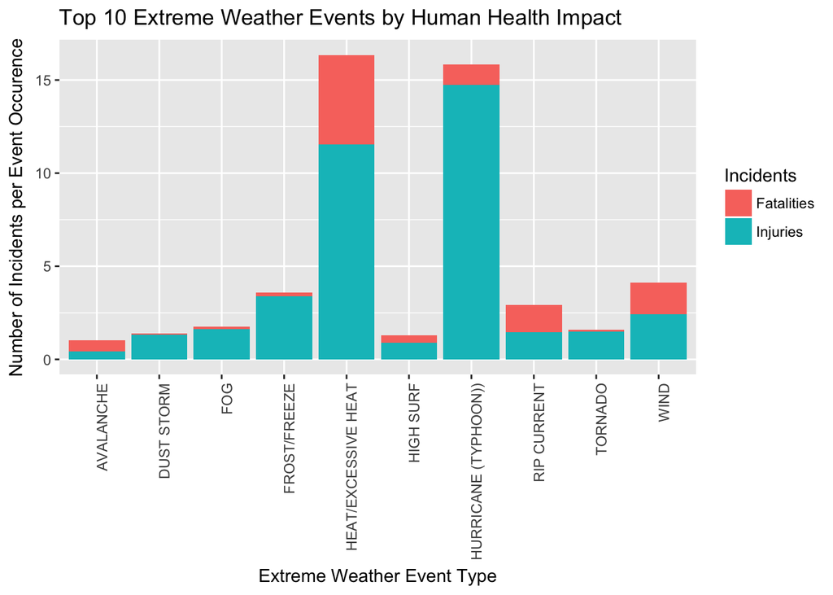

```r
ggplot(worstevents,aes(x=EVCLASS,y=value,fill=Incidents))+geom_bar(stat="identity",position="stack") + theme(axis.text.x = element_text(angle=90,hjust = 1)) + xlab("Extreme Weather Event Type") + ylab("Number of Incidents per Event Occurence") + ggtitle("Top 10 Extreme Weather Events by Human Health Impact")
```

### Analysis of storm events on U.S. economy.

First, let’s get our data ready. We start by filtering out any observations which record neither property nor crop damage. After that, we will replace the exponent column abbreviations with real numbers (i.e. 1,000 for “K”, etc.). Finally, we will multiply those numbers by the listed amount of damage and put the results into new columns, grouped and summarized by Event Type. We will then divide the total damage per event by the number of recorded events to determine average damage per occurance. We will express the financial amount in thousands.

```r
economicdata <- economicdata %>% filter(PROPDMG>0|CROPDMG>0)

economicdata$PROPDMGEXP <- gsub("^h$","100",economicdata$PROPDMGEXP,ignore.case=TRUE)
economicdata$PROPDMGEXP <- gsub("^k$","1000",economicdata$PROPDMGEXP,ignore.case=TRUE)
economicdata$PROPDMGEXP <- gsub("^m$","1000000",economicdata$PROPDMGEXP,ignore.case=TRUE)
economicdata$PROPDMGEXP <- gsub("^b$","1000000000",economicdata$PROPDMGEXP,ignore.case=TRUE)
economicdata$PROPDMGEXP <- as.numeric(economicdata$PROPDMGEXP)
economicdata$CROPDMGEXP <- gsub("^h$","100",economicdata$CROPDMGEXP,ignore.case=TRUE)
economicdata$CROPDMGEXP <- gsub("^k$","1000",economicdata$CROPDMGEXP,ignore.case=TRUE)
economicdata$CROPDMGEXP <- gsub("^m$","1000000",economicdata$CROPDMGEXP,ignore.case=TRUE)
economicdata$CROPDMGEXP <- gsub("^b$","1000000000",economicdata$CROPDMGEXP,ignore.case=TRUE)
economicdata$CROPDMGEXP <- as.numeric(economicdata$CROPDMGEXP)
library(imputeTS)
economicdata$PROPDMGEXP <- na.replace(economicdata$PROPDMGEXP,fill=0)
economicdata$CROPDMGEXP <- na.replace(economicdata$CROPDMGEXP,fill=0)

economicdamage <- economicdata %>% select(EVCLASS,EVTYPE,PROPDMG:CROPDMGEXP) %>% mutate(PROPDOL_K = PROPDMG*PROPDMGEXP/1000, CROPDOL_K = CROPDMG*CROPDMGEXP/1000) %>% select(EVCLASS,EVTYPE,PROPDOL_K,CROPDOL_K) %>% group_by(EVCLASS,EVTYPE) %>% mutate(TOTALDOL_K = PROPDOL_K+CROPDOL_K) %>% summarize_each(funs(sum)) %>% arrange(desc(TOTALDOL_K))

economicdamage <- merge(economicdamage,event_occurence,by.x="EVTYPE",by.y='row.names')
economicdamage <- economicdamage %>% mutate(PROPDAM_Event = PROPDOL_K/Frequency,CROPDAM_Event = CROPDOL_K/Frequency, TOTALDAM_Event = TOTALDOL_K/Frequency) %>% arrange(desc(TOTALDAM_Event))

head(economicdamage)
```

```
##              EVTYPE              EVCLASS PROPDOL_K CROPDOL_K TOTALDOL_K
## 1 HURRICANE/TYPHOON HURRICANE (TYPHOON))  69305840   2607873   71913713
## 2       STORM SURGE     STORM SURGE/TIDE  43323536         5   43323541
## 3         HURRICANE HURRICANE (TYPHOON))  11868319   2741910   14610229
## 4       RIVER FLOOD                FLOOD   5118946   5029459   10148404
## 5  STORM SURGE/TIDE     STORM SURGE/TIDE   4641188       850    4642038
## 6    TROPICAL STORM       TROPICAL STORM   7703891    678346    8382237
##   Frequency PROPDAM_Event CROPDAM_Event TOTALDAM_Event
## 1        88     787566.36  2.963492e+04      817201.28
## 2       261     165990.56  1.915709e-02      165990.58
## 3       174      68208.73  1.575810e+04       83966.83
## 4       173      29589.28  2.907202e+04       58661.30
## 5       148      31359.38  5.743243e+00       31365.12
## 6       690      11165.06  9.831101e+02       12148.17
```

We now have a table that shows total econonmic damage per event type and class. Let’s find the top 10 by class and do a quick plot like we did for human health impact.

```r
highestdamage <- economicdamage %>% select(EVCLASS,Frequency,PROPDOL_K:TOTALDAM_Event) %>% group_by(EVCLASS) %>% summarize_each(funs(sum)) %>% rename(Property = PROPDOL_K,Crop = CROPDOL_K) %>% arrange(desc(TOTALDAM_Event))
head(highestdamage)
```

```
## # A tibble: 6 x 8
##                EVCLASS Frequency  Property     Crop TOTALDOL_K
##                  <chr>     <int>     <dbl>    <dbl>      <dbl>
## 1 HURRICANE (TYPHOON))       262  81174159  5349783   86523942
## 2     STORM SURGE/TIDE       409  47964724      855   47965579
## 3                FLOOD     82380 166902050 12233096  179135146
## 4         FROST/FREEZE      3831   3977576  6628424   10606001
## 5       TROPICAL STORM       750   7705628   678346    8383974
## 6              DROUGHT      2674   1052839 13972581   15025420
## # ... with 3 more variables: PROPDAM_Event <dbl>, CROPDAM_Event <dbl>,
## #   TOTALDAM_Event <dbl>
```

```r
totaldamage <- melt(select(highestdamage[1:10,],c(EVCLASS,Property:Crop
                                                  )))
```

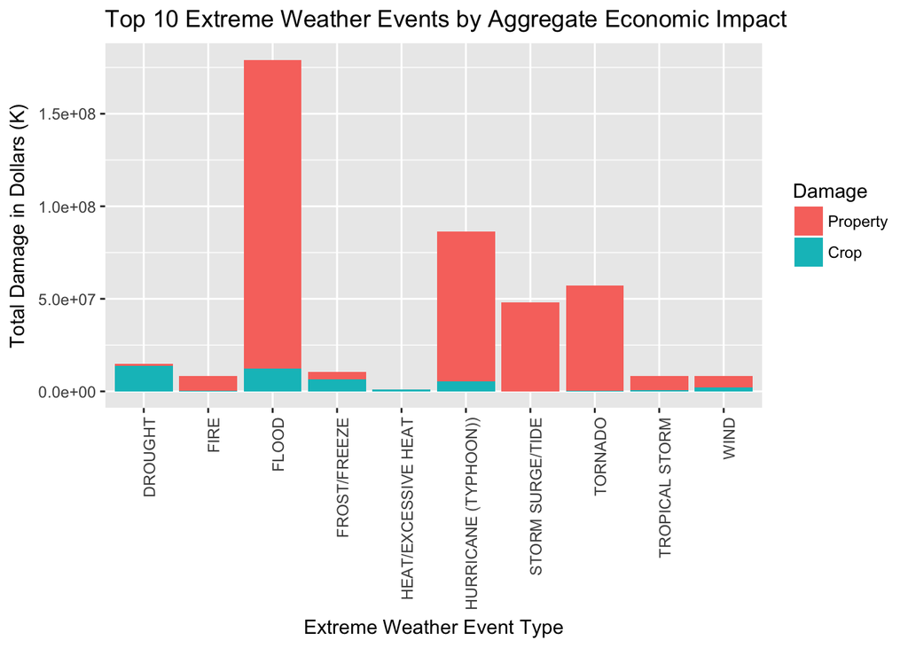

```r
totaldamage <- totaldamage %>% rename(Damage=variable)

ggplot(totaldamage,aes(x=EVCLASS,y=value,fill=Damage))+geom_bar(stat="identity",position="stack") + theme(axis.text.x = element_text(angle=90,hjust = 1)) + xlab("Extreme Weather Event Type") + ylab("Total Damage in Dollars (K)") + ggtitle("Top 10 Extreme Weather Events by Aggregate Economic Impact")
```

Now let’s see damage per event occurence.

```r
damageper <- melt(select(highestdamage[1:10,],c(EVCLASS,PROPDAM_Event:CROPDAM_Event)))
```

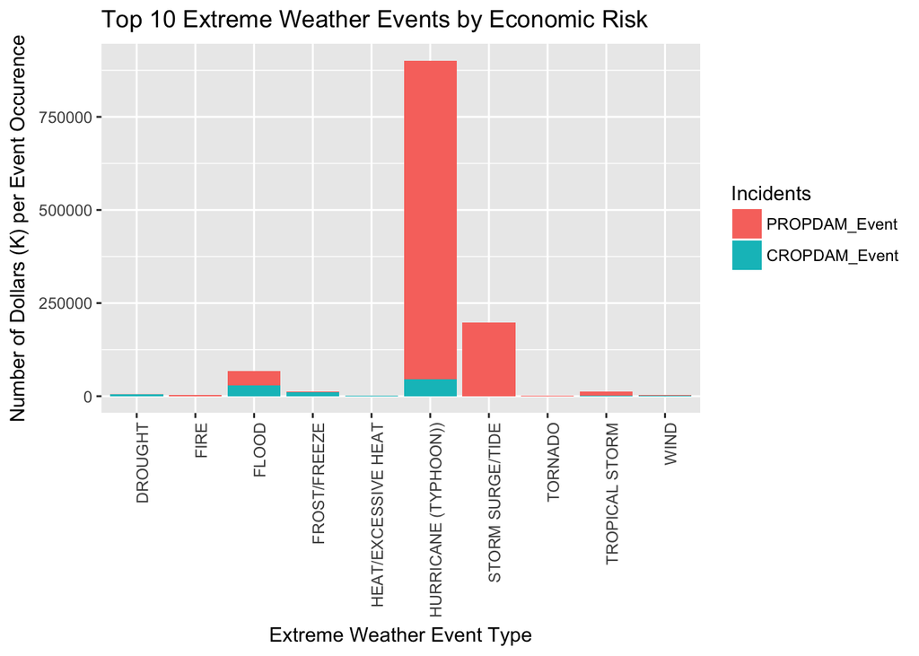

```r
damageper <- damageper %>% rename(Incidents=variable)

ggplot(damageper,aes(x=EVCLASS,y=value,fill=Incidents))+geom_bar(stat="identity",position="stack") + theme(axis.text.x = element_text(angle=90,hjust = 1)) + xlab("Extreme Weather Event Type") + ylab("Number of Dollars (K) per Event Occurence") + ggtitle("Top 10 Extreme Weather Events by Economic Risk")
```

It is very interesting to see the breakdown of both the aggregate damage value since 1950 as well as the amount spent per event (essentially the mean damage). We see that flood damage has been the most expensive as an aggregate, however, on a per event basis, hurricanes have by far.